# Embracing Uncertainty: Factor Structure and Associations with Internalizing Problems

Author

Leanna Wasilonski, Courtney Cockerham, Kyle Eichas

# Background

**Note**

Many young adults experience both a positive sense of future life possibilities and a negative sense of present instability (Arnett, 2004). Dual positive and negative subjective experiences of young adulthood reflect the uncertainty that characterizes this period of the life course. During this time, making choices and taking actions that give life direction and purpose requires young adults to *embrace* uncertainty (Jay, 2024). Embracing uncertainty is an orientation toward ambiguity characterized by positive appraisal, openness, and acceptance regarding the future.

Recognizing the dearth of available instruments for assessing positive attitudes towards uncertainty, Jay (2024) proposed a set of items that could be used to operationalize embracing uncertainty. The aim of the present study is to examine the measurement structure of these items, providing an initial psychometric evaluation of the **Embracing Uncertainty Scale (EUS)**.

## Construct Definition and Differential Definitions

For this study, we used Jay’s (2024) definition of *embracing uncertainty* as a positive orientation toward uncertainty characterized by openness and acceptance regarding an unknown future. Rather than simply tolerating uncertainty, embracing uncertainty involves positively appraising and actively engaging with uncertain future outcomes. Related work on curiosity identifies a facet of embracing uncertainty that is defined as a “willingness to embrace novel, uncertain, and unpredictable nature of everyday life” (Kashdan et al., 2009, p. 987). Jay (2024) extends this emphasis on the willingness to embrace uncertainty to also include positive appraisal and continued engagement in navigating an unsettled future despite life’s uncertainties.

- Embracing uncertainty differs from *confidence* in that confidence is the belief in one’s ability to succeed, while embracing uncertainty involves remaining open to new experiences and situations even when success and clarity are unknown.
- Embracing uncertainty differs from *internal locus of control* in that internal locus of control emphasizes the belief that one can control the outcome of life’s events, whereas embracing uncertainty releases the need to control or influence outcomes and accepts that some outcomes cannot be fully predicted.
- Embracing uncertainty differs from *tolerance of ambiguity* in that tolerance of ambiguity refers to enduring unclear or complex situations in the present moment, whereas embracing uncertainty openly welcomes and seeks out unpredictability and has a positive attitude towards an unknown future.
- Embracing uncertainty differs from *agency* in that agency is the capacity to intentionally produce certain effects by actions, whereas embracing uncertainty surrenders the need to control and is open to ambiguity.

**NoteItems**

| Item Name | Item Text |
| --- | --- |
|  | The following items are about how you feel about uncertainty in life. Please read the items and rate your agreement with each statement. |
| `eus1` | Unforeseen events make life exciting. |
| `eus2` | In life, it is often not possible, or even desirable, to have complete information. |
| `eus3` | Some of the best things in life are uncertain. |
| `eus4` | I look forward to life’s surprises. |
| `eus5` | It’s freeing not to be able to quantify where I stand sometimes. |
| `eus6` | When I am uncertain, I pay more attention to life. |
| `eus7` | When I am uncertain, I can think of more than one way ahead. |
| `eus8` | I don’t expect the future to be certain because so much is still up to me. |
| `eus9` | I don’t mind when life is not settled. |
| `eus10` | I enjoy imagining the future. |
| `eus11` | I find it liberating when there is not a right answer to things. |
| `eus12` | When faced with choices, I make a decision and I don’t look back. |
| `eus13` | I embrace uncertain situations. |

# Data Preparation

## Import Data

```r
# Data import
dat <- read_csv("data_help-seeking.csv") # Reads and stores original data

# Create data frame with only variables of interest
dat_vars <- dat |>
  dplyr::select(starts_with(c("eus","yips")))
```

## Rename Variables

```r
# Rename the columns
dat_vars <-
  dat_vars |>
  rename(
    eus1 = eus1_embracinguncertainty1,
    eus2 = eus2_embracinguncertainty2,
    eus3 = eus3_embracinguncertainty3,
    eus4 = eus4_embracinguncertainty4,
    eus5 = eus5_embracinguncertainty5,
    eus6 = eus6_embracinguncertainty6,
    eus7 = eus7_embracinguncertainty7,
    eus8 = eus8_embracinguncertainty8,
    eus9 = eus9_embracinguncertainty9,
    eus10 = eus10_embracinguncertainty10,
    eus11 = eus11_embracinguncertainty11,
    eus12 = eus12_embracinguncertainty12,
    eus13 = eus13_embracinguncertainty13,
    yips1 = yips1_internalizingproblems1,
    yips2 = yips2_internalizingproblems2,
    yips3 = yips3_internalizingproblems3,
    yips4 = yips4_internalizingproblems4,
    yips5 = yips5_internalizingproblems5,
    yips6 = yips6_internalizingproblems6,
    yips7 = yips7_internalizingproblems7,
    yips8 = yips8_internalizingproblems8,
    yips9 = yips9_internalizingproblems9,
    yips10 = yips10_internalizingproblems10)
```

## Rescale Variables

```r
# Check data (Generates a stats summary for newly renamed variables)
varNames <- grep("^(eus|yips)", names(dat_vars), value = TRUE)
summary(dat_vars[,varNames])

# Loop the POM function over all columns of data
for (i in 1:length(varNames)) {
  dat_vars[,varNames[i]] <- POM_fixed(x = dat_vars[,varNames[i]],
                                      min_x = 0,
                                      max_x = 100)*5
}
```

# Confirmatory Factor Analyses

## Measurement Model 1

**NoteModel Specifications**

- **Type**: One-factor
- **Indicators**: 13
- **Modifications**: None

### Factor Specification

```r
## Embracing Uncertainty 1 (One Factor)
model1 <- '
# Define the latent factors
eus =~ eus1 +
       eus2 +
       eus3 +
       eus4 +
       eus5 +
       eus6 +
       eus7 +
       eus8 +
       eus9 +
       eus10 +
       eus11 +
       eus12 +
       eus13

# Latent Variances (fixed to 1)
eus ~~ 1*eus

# Latent Intercepts (fixed to 0)
eus ~ 0*1
'
```

### Measurement Model 1: Results

**Plot**

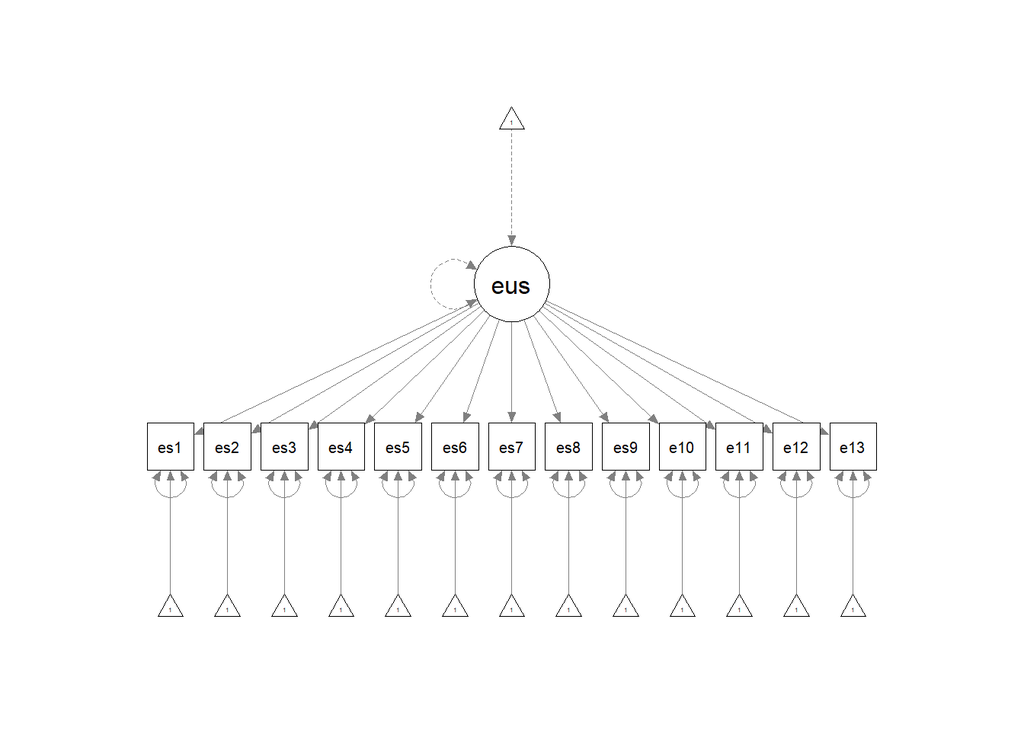

**Fit**

Model Fit Indices

| Measure | Value |
| --- | --- |
| χ² | 151.923 |
| df | 65.000 |
| p | 0.000 |
| CFI | 0.859 |
| TLI | 0.831 |
| RMSEA | 0.081 |
| SRMR | 0.063 |

**Parameter Estimates**

Factor Loadings

|  |  |  | Coeff | SE | 95% CI | z | p |
| --- | --- | --- | --- | --- | --- | --- | --- |
| eus | =~ | eus1 | 0.673 | 0.046 | 0.584,0.762 | 14.747 | 0.000 |
| eus | =~ | eus2 | 0.312 | 0.071 | 0.172,0.451 | 4.378 | 0.000 |
| eus | =~ | eus3 | 0.632 | 0.049 | 0.535,0.728 | 12.862 | 0.000 |
| eus | =~ | eus4 | 0.662 | 0.047 | 0.571,0.753 | 14.214 | 0.000 |
| eus | =~ | eus5 | 0.575 | 0.054 | 0.469,0.682 | 10.562 | 0.000 |
| eus | =~ | eus6 | 0.293 | 0.070 | 0.155,0.431 | 4.161 | 0.000 |
| eus | =~ | eus7 | 0.369 | 0.067 | 0.237,0.5 | 5.498 | 0.000 |
| eus | =~ | eus8 | 0.226 | 0.074 | 0.081,0.371 | 3.056 | 0.002 |
| eus | =~ | eus9 | 0.705 | 0.043 | 0.622,0.789 | 16.495 | 0.000 |
| eus | =~ | eus10 | 0.270 | 0.071 | 0.131,0.409 | 3.799 | 0.000 |
| eus | =~ | eus11 | 0.549 | 0.055 | 0.441,0.658 | 9.904 | 0.000 |
| eus | =~ | eus12 | 0.466 | 0.061 | 0.346,0.586 | 7.608 | 0.000 |
| eus | =~ | eus13 | 0.761 | 0.037 | 0.688,0.835 | 20.347 | 0.000 |

**Results Plot**

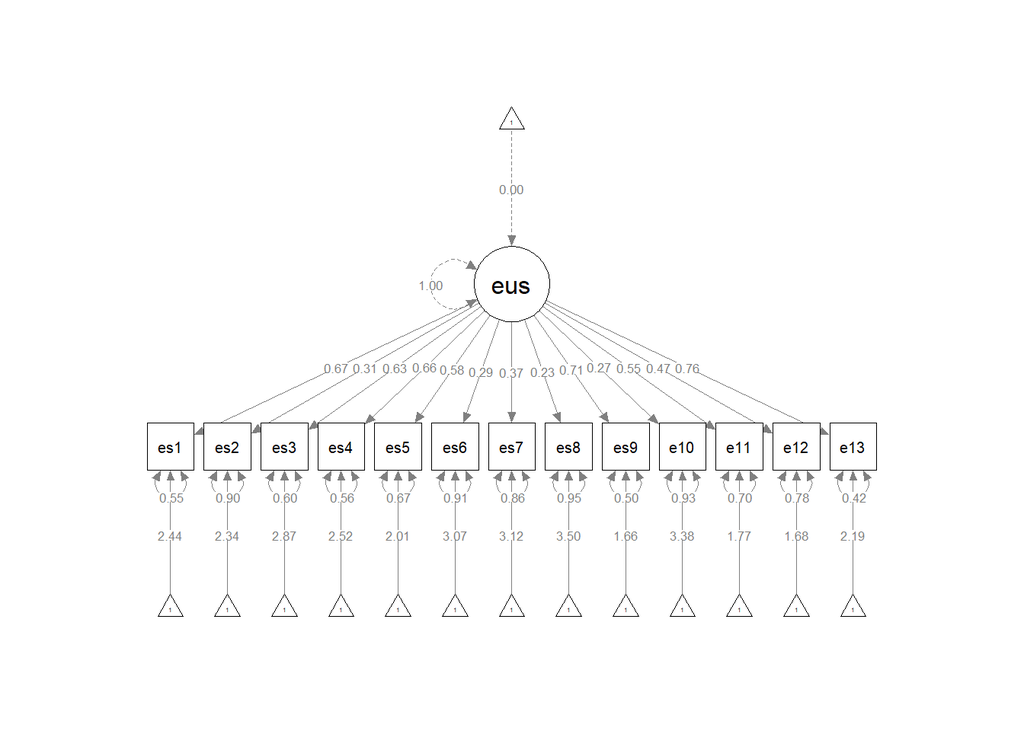

## Measurement Model 2

**NoteModel Specifications**

- **Type**: Three-factor
- **Indicators**: 13
- **Modifications**: None

### Factor Specifications

```r
## Embracing Uncertainty 2 (Three Factor)
model2 <-'
# Define the latent factors
pos_eus =~ eus1 +
           eus2 +
           eus3 +
           eus5 +
           eus9 +
           eus11 +
           eus13

agen_eus =~ eus6 +
            eus7 +
            eus12

futu_eus =~ eus4 +
            eus8 +
            eus10

# Latent Variances (fixed to 1)
pos_eus ~~ 1*pos_eus
agen_eus ~~ 1*agen_eus
futu_eus ~~ 1*futu_eus

# Latent Intercepts (fixed to 0)
pos_eus ~ 0*1
agen_eus ~ 0*1
futu_eus ~ 0*1
'
```

### Measurement Model 2: Results

**Plot**

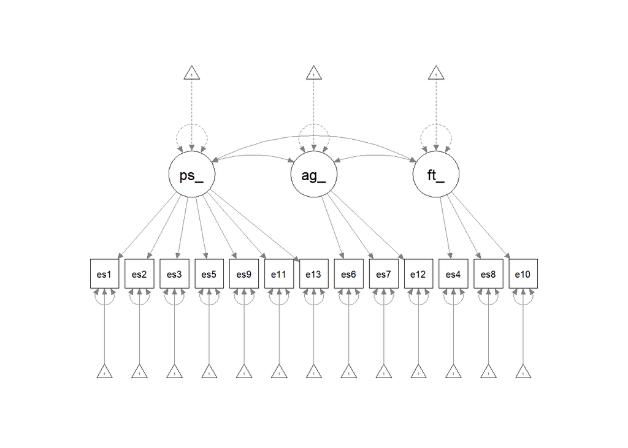

**Fit**

Model Fit Indices

| Measure | Value |
| --- | --- |
| χ² | 142.635 |
| df | 62.000 |
| p | 0.000 |
| CFI | 0.869 |
| TLI | 0.836 |
| RMSEA | 0.080 |
| SRMR | 0.063 |

**Parameter Estimates**

Factor Loadings

|  |  |  | Coeff | SE | 95% CI | z | p |
| --- | --- | --- | --- | --- | --- | --- | --- |
| pos_eus | =~ | eus1 | 0.674 | 0.045 | 0.585,0.763 | 14.817 | 0.000 |
| pos_eus | =~ | eus2 | 0.308 | 0.071 | 0.168,0.448 | 4.316 | 0.000 |
| pos_eus | =~ | eus3 | 0.628 | 0.050 | 0.531,0.725 | 12.651 | 0.000 |
| pos_eus | =~ | eus5 | 0.577 | 0.054 | 0.471,0.684 | 10.620 | 0.000 |
| pos_eus | =~ | eus9 | 0.707 | 0.043 | 0.624,0.791 | 16.606 | 0.000 |
| pos_eus | =~ | eus11 | 0.548 | 0.056 | 0.439,0.657 | 9.853 | 0.000 |
| pos_eus | =~ | eus13 | 0.761 | 0.037 | 0.688,0.835 | 20.312 | 0.000 |
| agen_eus | =~ | eus6 | 0.386 | 0.081 | 0.227,0.544 | 4.766 | 0.000 |
| agen_eus | =~ | eus7 | 0.448 | 0.076 | 0.298,0.597 | 5.853 | 0.000 |
| agen_eus | =~ | eus12 | 0.592 | 0.076 | 0.444,0.741 | 7.815 | 0.000 |
| futu_eus | =~ | eus4 | 0.776 | 0.096 | 0.588,0.964 | 8.091 | 0.000 |
| futu_eus | =~ | eus8 | 0.189 | 0.088 | 0.017,0.36 | 2.154 | 0.031 |
| futu_eus | =~ | eus10 | 0.306 | 0.077 | 0.155,0.458 | 3.967 | 0.000 |
| pos_eus | ~~ | agen_eus | 0.784 | 0.086 | 0.616,0.952 | 9.147 | 0.000 |
| pos_eus | ~~ | futu_eus | 0.873 | 0.106 | 0.665,1.082 | 8.218 | 0.000 |
| agen_eus | ~~ | futu_eus | 0.547 | 0.142 | 0.269,0.826 | 3.856 | 0.000 |

**Results Plot**

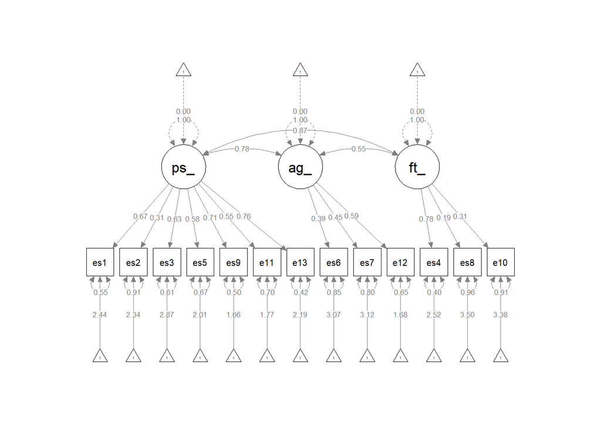

## Measurement Model 3

**NoteModel Specifications**

- **Type**: Two-factor
- **Indicators**: 13
- **Modifications**: None

### Factor Specifications

```r
## Embracing Uncertainty 3 (Two Factor)
model3 <-'
# Define the latent factors
pos_eus =~ eus1 +
           eus2 +
           eus3 +
           eus4 +
           eus5 +
           eus9 +
           eus10 +
           eus11 +
           eus13

#Agentic engagement with uncertainty
agt_eus =~ eus6 +
           eus7 +
           eus8 +
           eus12

#Latent Variances (fixed to 1)
pos_eus ~~ 1*pos_eus
agt_eus ~~ 1*agt_eus

# Latent Intercepts (fixed to 0)
pos_eus ~ 0*1
agt_eus ~ 0*1
'
```

### Measurement Model 3: Results

**Plot**

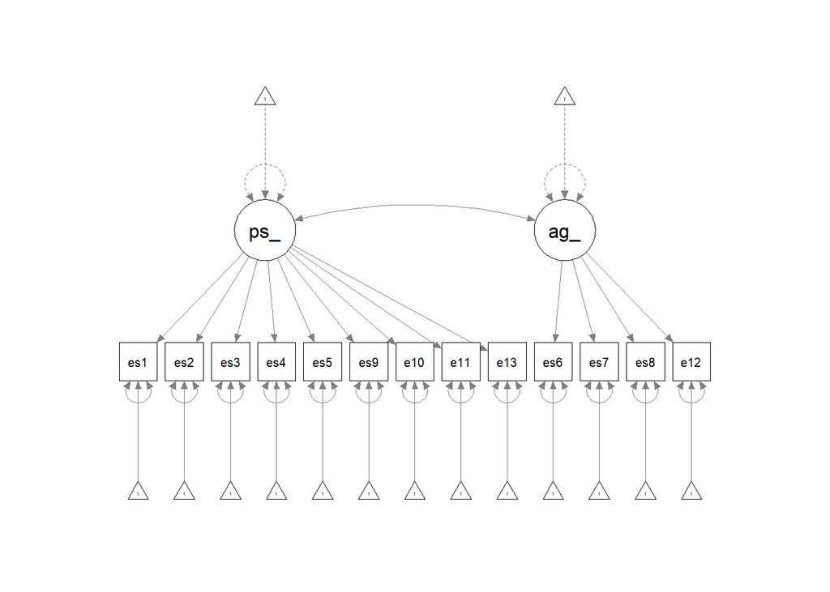

**Fit**

Model Fit Indices

| Measure | Value |
| --- | --- |
| χ² | 142.813 |
| df | 64.000 |
| p | 0.000 |
| CFI | 0.872 |
| TLI | 0.844 |
| RMSEA | 0.078 |
| SRMR | 0.060 |

**Parameter Estimates**

Factor Loadings

|  |  |  | Coeff | SE | 95% CI | z | p |
| --- | --- | --- | --- | --- | --- | --- | --- |
| pos_eus | =~ | eus1 | 0.678 | 0.045 | 0.589,0.766 | 14.928 | 0 |
| pos_eus | =~ | eus2 | 0.313 | 0.071 | 0.173,0.452 | 4.388 | 0 |
| pos_eus | =~ | eus3 | 0.636 | 0.049 | 0.54,0.732 | 13.020 | 0 |
| pos_eus | =~ | eus4 | 0.670 | 0.046 | 0.579,0.76 | 14.544 | 0 |
| pos_eus | =~ | eus5 | 0.575 | 0.055 | 0.468,0.683 | 10.527 | 0 |
| pos_eus | =~ | eus9 | 0.703 | 0.043 | 0.618,0.787 | 16.272 | 0 |
| pos_eus | =~ | eus10 | 0.267 | 0.071 | 0.127,0.406 | 3.742 | 0 |
| pos_eus | =~ | eus11 | 0.550 | 0.056 | 0.442,0.659 | 9.913 | 0 |
| pos_eus | =~ | eus13 | 0.761 | 0.038 | 0.687,0.835 | 20.195 | 0 |
| agt_eus | =~ | eus6 | 0.403 | 0.080 | 0.247,0.56 | 5.047 | 0 |
| agt_eus | =~ | eus7 | 0.464 | 0.077 | 0.314,0.615 | 6.048 | 0 |
| agt_eus | =~ | eus8 | 0.296 | 0.084 | 0.131,0.461 | 3.509 | 0 |
| agt_eus | =~ | eus12 | 0.573 | 0.073 | 0.431,0.715 | 7.892 | 0 |
| pos_eus | ~~ | agt_eus | 0.751 | 0.079 | 0.597,0.905 | 9.548 | 0 |

**Results Plot**

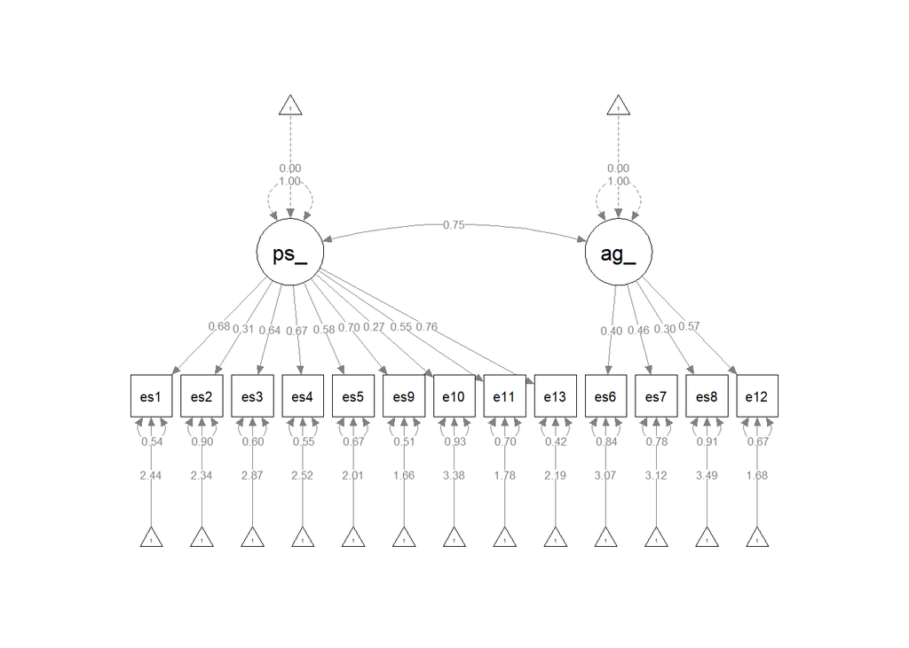

## Measurement Model 4

**NoteModel Specifications**

- **Type**: Two-factor
- **Indicators**: 10
- **Modifications**: Remove eus2, eus8, eus10; allow residual correlation: eus5 and eus9

### Factor Specifications

```r
## Embracing Uncertainty 4 (Modified Two Factor)
model4 <-'
# Define the latent factors
pos_eus =~ eus1 +
           eus3 +
           eus4 +
           eus5 +
           eus9 +
           eus11 +
           eus13

#Agentic engagement with uncertainty
agt_eus =~ eus6 +
           eus7 +
           eus12

#Latent Variances (fixed to 1)
pos_eus ~~ 1*pos_eus
agt_eus ~~ 1*agt_eus

# Latent Intercepts (fixed to 0)
pos_eus ~ 0*1
agt_eus ~ 0*1

# Correlated Residual
eus5 ~~ eus9
'
```

### Measurement Model 4: Results

**Plot**

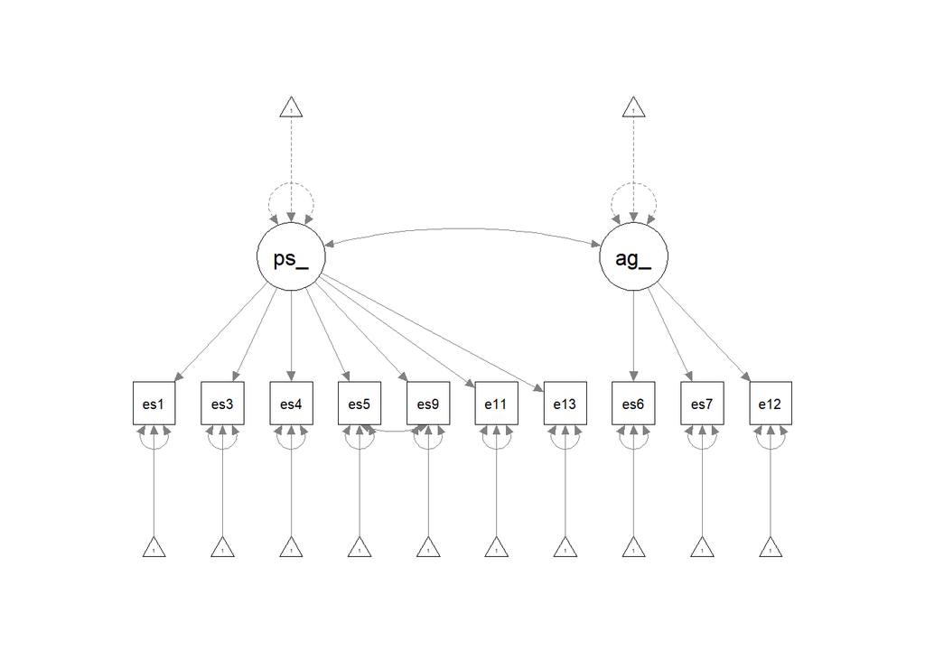

**Fit**

Model Fit Indices

| Measure | Value |
| --- | --- |
| χ² | 68.640 |
| df | 33.000 |
| p | 0.000 |
| CFI | 0.935 |
| TLI | 0.911 |
| RMSEA | 0.073 |
| SRMR | 0.050 |

**Parameter Estimates**

Factor Loadings

|  |  |  | Coeff | SE | 95% CI | z | p |
| --- | --- | --- | --- | --- | --- | --- | --- |
| pos_eus | =~ | eus1 | 0.682 | 0.046 | 0.592,0.772 | 14.846 | 0.000 |
| pos_eus | =~ | eus3 | 0.645 | 0.049 | 0.549,0.74 | 13.232 | 0.000 |
| pos_eus | =~ | eus4 | 0.674 | 0.046 | 0.583,0.765 | 14.507 | 0.000 |
| pos_eus | =~ | eus5 | 0.528 | 0.060 | 0.411,0.645 | 8.813 | 0.000 |
| pos_eus | =~ | eus9 | 0.681 | 0.046 | 0.591,0.771 | 14.878 | 0.000 |
| pos_eus | =~ | eus11 | 0.537 | 0.057 | 0.425,0.648 | 9.407 | 0.000 |
| pos_eus | =~ | eus13 | 0.780 | 0.037 | 0.707,0.853 | 21.007 | 0.000 |
| agt_eus | =~ | eus6 | 0.391 | 0.082 | 0.231,0.551 | 4.791 | 0.000 |
| agt_eus | =~ | eus7 | 0.445 | 0.078 | 0.291,0.598 | 5.678 | 0.000 |
| agt_eus | =~ | eus12 | 0.592 | 0.078 | 0.44,0.745 | 7.609 | 0.000 |
| eus5 | ~~ | eus9 | 0.257 | 0.078 | 0.104,0.409 | 3.291 | 0.001 |
| pos_eus | ~~ | agt_eus | 0.746 | 0.087 | 0.576,0.917 | 8.597 | 0.000 |

**Results Plot**

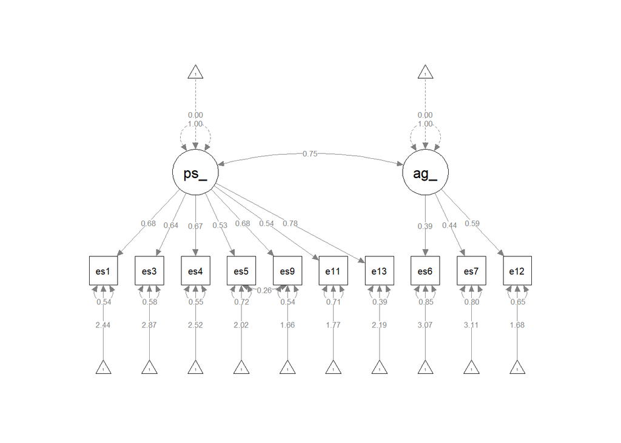

## Measurement Model 5: Youth Internalizing Problems Scale

**NoteModel Specifications**

- **Type**: One-factor
- **Indicators**: 10
- **Modifications**: None

### Factor Specifications

```r
## Youth Internalizing Problems Scale
model5 <-'
# Define the latent factors
intrprob =~ yips1 +
            yips2 +
            yips3 +
            yips4 +
            yips5 +
            yips6 +
            yips7 +
            yips8 +
            yips9 +
            yips10

#Latent Variances (fixed to 1)
intrprob ~~ 1*intrprob

# Latent Intercepts (fixed to 0)
intrprob ~ 0*1
'
```

### Measurement Model 5: Results

**Plot**

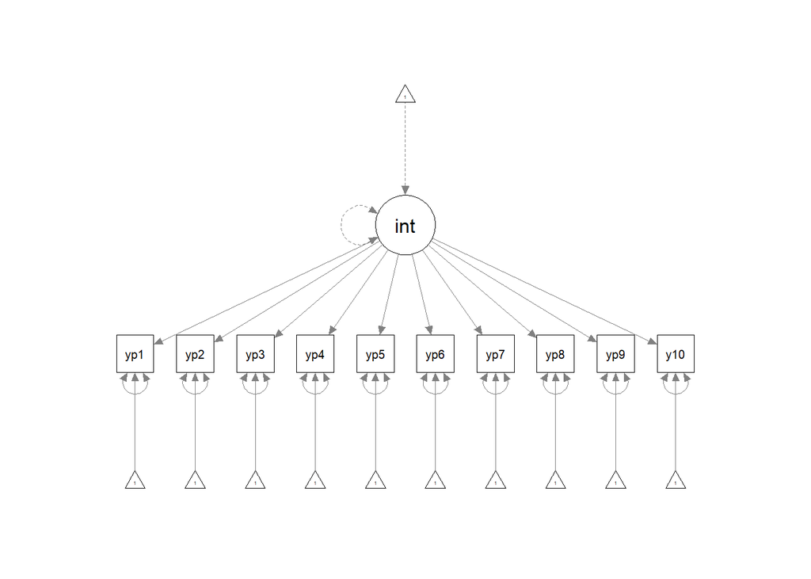

**Fit**

Model Fit Indices

| Measure | Value |
| --- | --- |
| χ² | 70.385 |
| df | 35.000 |
| p | 0.000 |
| CFI | 0.959 |
| TLI | 0.947 |
| RMSEA | 0.071 |
| SRMR | 0.041 |

**Parameter Estimates**

Factor Loadings

|  |  |  | Coeff | SE | 95% CI | z | p |
| --- | --- | --- | --- | --- | --- | --- | --- |
| intrprob | =~ | yips1 | 0.732 | 0.037 | 0.659,0.805 | 19.664 | 0 |
| intrprob | =~ | yips2 | 0.705 | 0.040 | 0.627,0.784 | 17.582 | 0 |
| intrprob | =~ | yips3 | 0.681 | 0.042 | 0.599,0.763 | 16.213 | 0 |
| intrprob | =~ | yips4 | 0.606 | 0.049 | 0.511,0.702 | 12.396 | 0 |
| intrprob | =~ | yips5 | 0.791 | 0.031 | 0.73,0.852 | 25.502 | 0 |
| intrprob | =~ | yips6 | 0.715 | 0.039 | 0.638,0.791 | 18.314 | 0 |
| intrprob | =~ | yips7 | 0.690 | 0.041 | 0.609,0.771 | 16.700 | 0 |
| intrprob | =~ | yips8 | 0.654 | 0.045 | 0.566,0.742 | 14.573 | 0 |
| intrprob | =~ | yips9 | 0.744 | 0.036 | 0.674,0.814 | 20.685 | 0 |
| intrprob | =~ | yips10 | 0.497 | 0.057 | 0.385,0.609 | 8.666 | 0 |

**Results Plot**

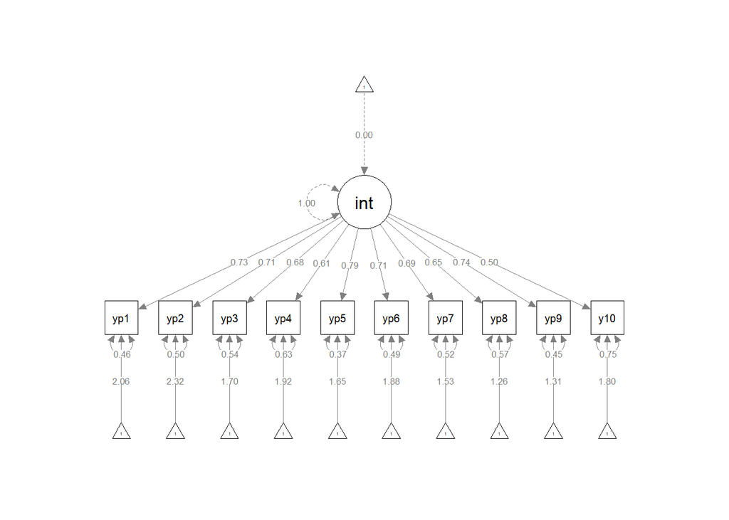

### Parceling

```r
## Internalizing Problems (Balanced Parceling)
# Create parcels using the Balancing Technique
dat_vars$yips_p1 <- rowMeans(dat_vars[ , c("yips1",
                                           "yips2",
                                           "yips4")],
                                na.rm = TRUE)

dat_vars$yips_p2 <- rowMeans(dat_vars[ , c("yips3",
                                           "yips6",
                                           "yips8")],
                                na.rm = TRUE)

dat_vars$yips_p3 <- rowMeans(dat_vars[ , c("yips5",
                                           "yips7",
                                           "yips9",
                                           "yips10")],
                                na.rm = TRUE)
```

## Measurement Model 6: Embracing Uncertainty and Internalizing Problems

**NoteModel Specifications**

- **Type**: Three-factor
- **Indicators**: 13
- **Modifications**: Remove eus2, eus8, eus10; allow residual correlation: eus5 and eus9; add yips parcels and intprob factor

### Factor Specifications

```r
## Embracing Uncertainty and Internalizing Problems
model6 <-'
# Define the latent factors
pos_eus =~ eus1 +
           eus3 +
           eus4 +
           eus5 +
           eus9 +
           eus11 +
           eus13

#Agentic engagement with uncertainty
agt_eus =~ eus6 +
           eus7 +
           eus12

#Internalizing problems
intprob =~ yips_p1 +
           yips_p2 +
           yips_p3

#Latent Variances (fixed to 1)
pos_eus ~~ 1*pos_eus
agt_eus ~~ 1*agt_eus
intprob ~~ 1*intprob

# Latent Intercepts (fixed to 0)
pos_eus ~ 0*1
agt_eus ~ 0*1
intprob ~ 0*1

# Correlated Residual
eus5 ~~ eus9
'
```

### Measurement Model 6: Results

**Plot**

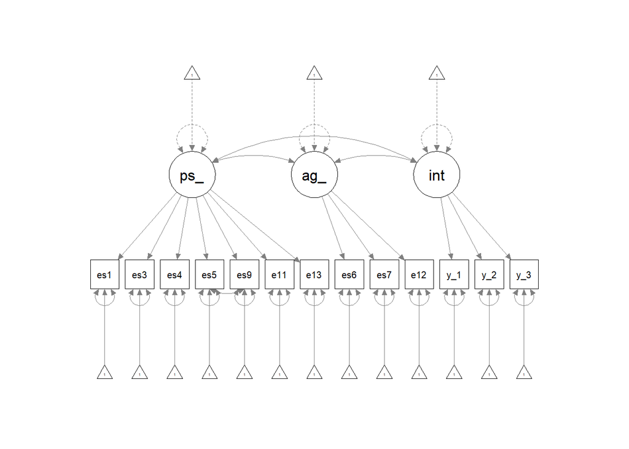

**Fit**

Model Fit Indices

| Measure | Value |
| --- | --- |
| χ² | 117.817 |
| df | 61.000 |
| p | 0.000 |
| CFI | 0.940 |
| TLI | 0.923 |
| RMSEA | 0.067 |
| SRMR | 0.058 |

**Parameter Estimates**

Factor Loadings

|  |  |  | Coeff | SE | 95% CI | z | p |
| --- | --- | --- | --- | --- | --- | --- | --- |
| pos_eus | =~ | eus1 | 0.688 | 0.045 | 0.599,0.777 | 15.180 | 0.000 |
| pos_eus | =~ | eus3 | 0.640 | 0.049 | 0.544,0.736 | 13.067 | 0.000 |
| pos_eus | =~ | eus4 | 0.683 | 0.046 | 0.594,0.773 | 14.968 | 0.000 |
| pos_eus | =~ | eus5 | 0.522 | 0.060 | 0.404,0.64 | 8.649 | 0.000 |
| pos_eus | =~ | eus9 | 0.682 | 0.046 | 0.593,0.772 | 14.960 | 0.000 |
| pos_eus | =~ | eus11 | 0.535 | 0.057 | 0.423,0.647 | 9.366 | 0.000 |
| pos_eus | =~ | eus13 | 0.773 | 0.038 | 0.699,0.847 | 20.498 | 0.000 |
| agt_eus | =~ | eus6 | 0.355 | 0.083 | 0.192,0.518 | 4.263 | 0.000 |
| agt_eus | =~ | eus7 | 0.432 | 0.078 | 0.28,0.584 | 5.563 | 0.000 |
| agt_eus | =~ | eus12 | 0.632 | 0.079 | 0.477,0.787 | 8.002 | 0.000 |
| intprob | =~ | yips_p1 | 0.858 | 0.026 | 0.807,0.909 | 32.891 | 0.000 |
| intprob | =~ | yips_p2 | 0.859 | 0.026 | 0.808,0.909 | 33.273 | 0.000 |
| intprob | =~ | yips_p3 | 0.864 | 0.026 | 0.814,0.914 | 33.683 | 0.000 |
| eus5 | ~~ | eus9 | 0.261 | 0.078 | 0.109,0.414 | 3.361 | 0.001 |
| pos_eus | ~~ | agt_eus | 0.733 | 0.089 | 0.559,0.908 | 8.234 | 0.000 |
| pos_eus | ~~ | intprob | -0.309 | 0.075 | -0.455,-0.162 | -4.128 | 0.000 |
| agt_eus | ~~ | intprob | -0.394 | 0.098 | -0.586,-0.201 | -4.002 | 0.000 |

**Results Plot**

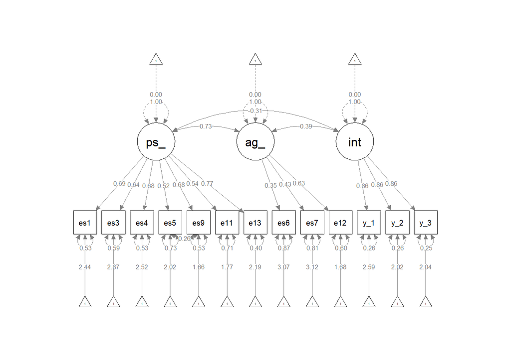

# Structural Equation Modeling

## Structural Regression Model: Embracing Uncertainty and Internalizing Problems

**NoteModel Specifications**

- **Type**: Three-factor
- **Indicators**: 13
- **Modifications**: Remove eus2, eus8, eus10; allow residual correlation: eus5 and eus9; add yips parcels and intprob factor; add structural regression paths

### Factor Specifications

```r
## Embracing Uncertainty and Internalizing Problems
model7 <-'
# Define the latent factors
pos_eus =~ eus1 +
           eus3 +
           eus4 +
           eus5 +
           eus9 +
           eus11 +
           eus13

#Agentic engagement with uncertainty
agt_eus =~ eus6 +
           eus7 +
           eus12

#Internalizing problems
intprob =~ yips_p1 +
           yips_p2 +
           yips_p3

#Latent Variances (fixed to 1)
pos_eus ~~ 1*pos_eus
agt_eus ~~ 1*agt_eus
intprob ~~ 1*intprob

# Latent Intercepts (fixed to 0)
pos_eus ~ 0*1
agt_eus ~ 0*1
intprob ~ 0*1

# Correlated Residual
eus5 ~~ eus9

#Structural model
intprob ~ pos_eus
intprob ~~ agt_eus
'
```

### Structural Regression Model: Results

**Plot**

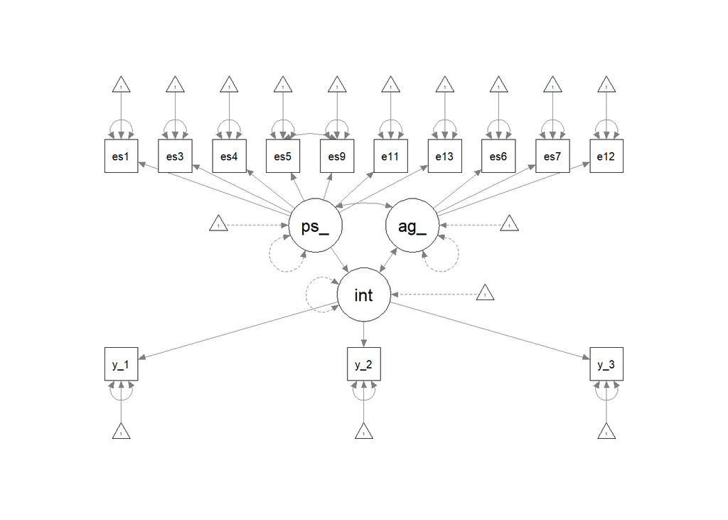

**Fit**

Model Fit Indices

| Measure | Value |
| --- | --- |
| χ² | 117.817 |
| df | 61.000 |
| p | 0.000 |
| CFI | 0.940 |
| TLI | 0.923 |
| RMSEA | 0.067 |
| SRMR | 0.058 |

**Parameter Estimates**

Factor Loadings

|  |  |  | Coeff | SE | 95% CI | z | p |
| --- | --- | --- | --- | --- | --- | --- | --- |
| pos_eus | =~ | eus1 | 0.688 | 0.045 | 0.599,0.777 | 15.180 | 0.000 |
| pos_eus | =~ | eus3 | 0.640 | 0.049 | 0.544,0.736 | 13.067 | 0.000 |
| pos_eus | =~ | eus4 | 0.684 | 0.046 | 0.594,0.773 | 14.968 | 0.000 |
| pos_eus | =~ | eus5 | 0.522 | 0.060 | 0.404,0.64 | 8.649 | 0.000 |
| pos_eus | =~ | eus9 | 0.682 | 0.046 | 0.593,0.772 | 14.960 | 0.000 |
| pos_eus | =~ | eus11 | 0.535 | 0.057 | 0.423,0.647 | 9.366 | 0.000 |
| pos_eus | =~ | eus13 | 0.773 | 0.038 | 0.699,0.847 | 20.498 | 0.000 |
| agt_eus | =~ | eus6 | 0.355 | 0.083 | 0.192,0.518 | 4.263 | 0.000 |
| agt_eus | =~ | eus7 | 0.432 | 0.078 | 0.28,0.584 | 5.563 | 0.000 |
| agt_eus | =~ | eus12 | 0.632 | 0.079 | 0.477,0.787 | 8.002 | 0.000 |
| intprob | =~ | yips_p1 | 0.858 | 0.026 | 0.807,0.909 | 32.891 | 0.000 |
| intprob | =~ | yips_p2 | 0.859 | 0.026 | 0.808,0.909 | 33.273 | 0.000 |
| intprob | =~ | yips_p3 | 0.864 | 0.026 | 0.814,0.914 | 33.683 | 0.000 |
| eus5 | ~~ | eus9 | 0.261 | 0.078 | 0.109,0.414 | 3.361 | 0.001 |
| intprob | ~ | pos_eus | -0.309 | 0.075 | -0.455,-0.162 | -4.128 | 0.000 |
| agt_eus | ~~ | intprob | -0.176 | 0.096 | -0.365,0.013 | -1.826 | 0.068 |
| pos_eus | ~~ | agt_eus | 0.733 | 0.089 | 0.559,0.908 | 8.234 | 0.000 |

**Results Plot**

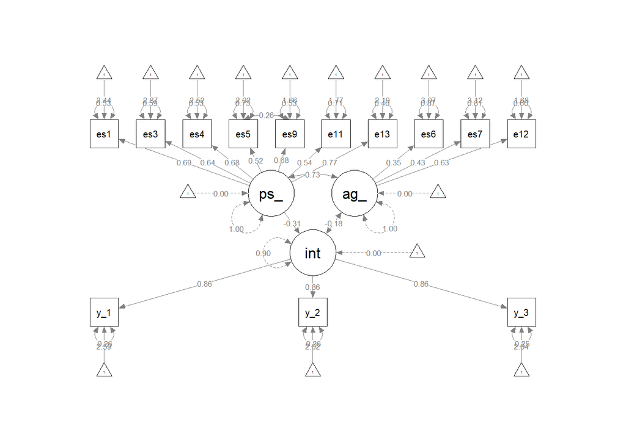

**Scatterplot with Factor Scores**

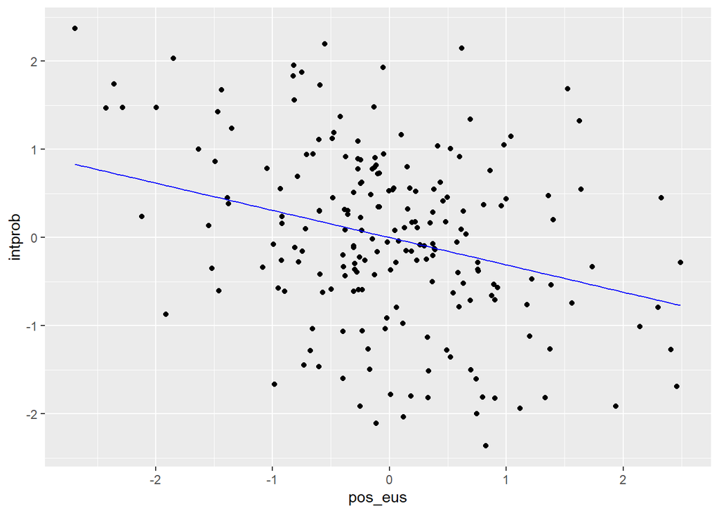

## Fit Table

*Figure 1 – Fit Table*

[output not shown]

aBased on Schreiber (2017), Table 3.

# Conclusion

We evaluated the latent structure of the Embracing Uncertainty Scale examined latent correlations with internalizing problems.One factor, two factor, and three factor embracing uncertainty models provided poor fit to the data and were therefore discarded. A modified two factor model showed acceptable model fit and was retained for further analyses. The two factors were *positive orientation toward uncertainty* and *agentic engagement with uncertainty*. Both factors were negatively correlated with internalizing problems.

These findings provide preliminary support for a two-factor structure of the Embracing Uncertainty Scale and a negative association with internalizing problems. Future research should examine convergent and discriminant validity to clarify how young adults appraise and engage with uncertainty. Examining the relationship between the proposed two factors of embracing uncertainty and other adaptive and maladaptive behaviors could inform the research literature and develop interventions to support college students’ positive development.